# Fire, Heat, and the Wildlife Recovery Gap in Australia

A complete pipeline: from raw fire-history shapefiles to an event-level test of whether post-fire heat widens the gap between vegetation greening and wildlife recovery

Authors

Hieu Do (SID: 540914928)

Van Duong (SID: 530745613)

Cong Thanh Vu (SID: 530784058)

Published

July 22, 2026

# 1 Setup

```python
import os
import json
import numpy as np
import pandas as pd
from scipy import stats
import statsmodels.formula.api as smf
from statsmodels.stats.outliers_influence import variance_inflation_factor
import matplotlib.pyplot as plt
import geopandas as gpd
import plotly.express as px

DATA_DIR = os.path.join(os.getcwd(), "..", "data")  # report lives in reports/, data lives in ../data
pd.set_option("display.width", 140)

def sig(p, thresh=0.05):
    """Small helper so every significance claim below is read live off the
    current p-value rather than typed as a fixed claim in prose."""
    return f"significant (p = {p:.3g} < {thresh})" if p < thresh else f"not significant (p = {p:.3g} ≥ {thresh})"
```

# 2 Introduction & research questions

Two connected questions are asked, in order:

> **Q1 (repeated-fire analysis).** Among divisions that keep re-burning, does vegetation (NDVI) or wildlife-sighting recovery show a progressively **weaker** trend the more often a division has had a major fire?

> **Q2 (post-fire heat analysis).** Does **post-fire heat exposure** widen the gap between vegetation recovery and wildlife recovery – i.e. does the reassuring “it’s green again” signal from satellite NDVI become a progressively worse proxy for “the habitat is fine” as the years after a fire get hotter?

Q1 is answered at **division level** using fire frequency alone. Q2 uses an **event-level** design (one row per major fire rather than one row per division) and adds daily heat exposure, allowing recovery to be tested against climate stress for each event. The two analyses are complementary: Q1 describes long-term patterns associated with repeated fire, while Q2 tests recovery following individual major fires.

| Dataset | Role | Source |
| --- | --- | --- |
| Fire history shapefiles, 7 states/territories | disturbance events: location, date, area | NSW (NPWS), QLD (QPWS), VIC (DEECA), SA, TAS, WA (DBCA), NT |
| `FAO/GAUL/2015/level2` admin-2 boundaries | LGA-level division geometries | Google Earth Engine |
| `AusENDVI-clim_MCD43A4...nc` | vegetation recovery signal (NDVI), 1982-2022 | Gap-filled MODIS NDVI climatology |
| ERA5-Land daily max temperature | post-fire heat exposure, relative to each division’s own baseline | Earth Engine, 1982-2022 |
| Koala / greater glider / yellow-bellied glider / yellow-tailed black-cockatoo / powerful owl / little lorikeet occurrences | wildlife presence (6 canopy/hollow-dependent indicator species) | Atlas of Living Australia (`galah`), 1990-2026, all 7 states/territories |

# 3 Data sources & processing pipeline

Each subsection explains how a source dataset was standardised for the analysis. Computationally intensive extraction steps – including reading large spatial files, processing the NetCDF vegetation product, and querying Earth Engine or the ALA API – are included for reproducibility but marked `eval: false`. The following executable cells load the derived analysis tables and report their current contents.

## 3.1 Fire history: loading and standardising 7 jurisdictions

Each state/territory publishes its fire-history layer with different column names and CRSes (NSW/QLD: GDA94 lat/lon, VIC: VicGrid94 projected metres, etc.) – reproject everything to EPSG:4326 and pull out a common `(state, start_date, area_ha, geometry)` schema so they can be combined. The Northern Territory layer carries its own per-record `state` attribute (border-adjacent fires are sometimes attributed to neighbouring QLD/WA/SA), so that attribute is used directly rather than hardcoding “Northern Territory” for every row.

**Appendix: loading & standardising the 7 state/territory fire-history layers**

```python
FIRE_SHAPEFILES = {
    "New South Wales": os.path.join(DATA_DIR, "NSW_fire_history", "NPWSFireHistory.shp"),
    "Queensland": os.path.join(DATA_DIR, "QLD_fire_history", "Fire_history___QPWS.shp"),
    "Victoria": os.path.join(DATA_DIR, "VIC_fire_history", "gda94_victoriagrid", "esrishape",
                              "whole_of_dataset", "victoria", "FIRE", "FIRE_HISTORY_LASTBURNT.shp"),
    "South Australia": os.path.join(DATA_DIR, "SA_fire_history", "FIREMGT_FireHistory_GDA2020.shp"),
    "Tasmania": os.path.join(DATA_DIR, "TAS_fire_history", "list_fire_history_statewide.gdb"),
    "Western Australia": os.path.join(DATA_DIR, "WA_fire_history", "DBCA_Fire_History_DBCA_060.shp"),
    "Northern Territory": os.path.join(DATA_DIR, "NA_fire_history", "NT_FireHistory_SHP.shp"),
}

def _naive_dates(series):
    # Concatenating tz-aware dates (e.g. TAS's File Geodatabase) with tz-naive
    # ones forces the combined column to dtype=object, breaking groupby min/max.
    parsed = pd.to_datetime(series, errors="coerce")
    if getattr(parsed.dt, "tz", None) is not None:
        parsed = parsed.dt.tz_localize(None)
    return parsed

def load_nsw(path):
    gdf = gpd.read_file(path).to_crs(4326)
    return gpd.GeoDataFrame({"state": "New South Wales", "start_date": _naive_dates(gdf["StartDate"]),
                              "area_ha": gdf["AreaHa"], "geometry": gdf.geometry}, crs=4326)

def load_qld(path):
    gdf = gpd.read_file(path).to_crs(4326)
    return gpd.GeoDataFrame({"state": "Queensland", "start_date": _naive_dates(gdf["ignitionda"]),
                              "area_ha": gdf["area_ha"], "geometry": gdf.geometry}, crs=4326)

def load_vic(path):
    gdf = gpd.read_file(path).to_crs(4326)
    return gpd.GeoDataFrame({"state": "Victoria", "start_date": _naive_dates(gdf["START_DATE"]),
                              "area_ha": gdf["AREA_HA"], "geometry": gdf.geometry}, crs=4326)

def load_sa(path):
    gdf = gpd.read_file(path).to_crs(4326)
    return gpd.GeoDataFrame({"state": "South Australia", "start_date": _naive_dates(gdf["FIREDATE"]),
                              "area_ha": gdf["HECTARES"], "geometry": gdf.geometry}, crs=4326)

def load_tas(path):
    gdf = gpd.read_file(path, layer="list_fire_history_statewide").to_crs(4326)  # File Geodatabase, needs the layer name
    return gpd.GeoDataFrame({"state": "Tasmania", "start_date": _naive_dates(gdf["IGN_DATE"]),
                              "area_ha": gdf["FIRE_AR_HA"], "geometry": gdf.geometry}, crs=4326)

def load_wa(path):
    gdf = gpd.read_file(path).to_crs(4326)
    return gpd.GeoDataFrame({"state": "Western Australia", "start_date": _naive_dates(gdf["fih_date1"]),
                              "area_ha": gdf["fih_hectar"], "geometry": gdf.geometry}, crs=4326)

def load_nt(path):
    # Border-adjacent records may carry a neighbouring state's own attribution --
    # not deduplicated against the QLD/WA/SA loaders above; flagged in Limitations.
    gdf = gpd.read_file(path).to_crs(4326)
    state_map = {"NT": "Northern Territory", "Qld": "Queensland", "QLD": "Queensland",
                 "WA": "Western Australia", "SA": "South Australia"}
    return gpd.GeoDataFrame({"state": gdf["state"].map(lambda s: state_map.get(s, s)),
                              "start_date": _naive_dates(gdf["ignition_d"]),
                              "area_ha": gdf["area_ha"], "geometry": gdf.geometry}, crs=4326)

fires = pd.concat([
    load_nsw(FIRE_SHAPEFILES["New South Wales"]), load_qld(FIRE_SHAPEFILES["Queensland"]),
    load_vic(FIRE_SHAPEFILES["Victoria"]), load_sa(FIRE_SHAPEFILES["South Australia"]),
    load_tas(FIRE_SHAPEFILES["Tasmania"]), load_wa(FIRE_SHAPEFILES["Western Australia"]),
    load_nt(FIRE_SHAPEFILES["Northern Territory"]),
], ignore_index=True)
fires = gpd.GeoDataFrame(fires, geometry="geometry", crs=4326)
fires = fires[fires.geometry.notna() & fires.geometry.is_valid]
print(f"Total fire records: {len(fires)}")
```

## 3.2 Admin-2 (LGA-level) division boundaries

Administrative division boundaries are obtained from Earth Engine’s `FAO/GAUL/2015/level2` collection and stored locally for reproducible spatial joins.

**Appendix: pulling admin-2 division boundaries from Earth Engine**

```python
import ee
import geemap

ADMIN2_CACHE = os.path.join(DATA_DIR, "au_admin2_boundaries.geojson")
REQUIRED_STATES = ["New South Wales", "Victoria", "Queensland", "South Australia",
                   "Tasmania", "Western Australia", "Northern Territory"]

ee.Initialize(project="project-868d3a54-1ed8-47ec-9ad")
gaul = ee.FeatureCollection("FAO/GAUL/2015/level2")
au_fc = (gaul.filter(ee.Filter.eq("ADM0_NAME", "Australia"))
              .filter(ee.Filter.inList("ADM1_NAME", REQUIRED_STATES)))
admin2 = geemap.ee_to_gdf(au_fc).set_crs(4326, allow_override=True)
admin2.to_file(ADMIN2_CACHE, driver="GeoJSON")
```

```python
admin2 = gpd.read_file(os.path.join(DATA_DIR, "au_admin2_boundaries.geojson"))[["ADM1_NAME", "ADM2_NAME", "geometry"]]
print(f"{len(admin2)} admin-2 divisions loaded, covering: {sorted(admin2['ADM1_NAME'].unique())}")
```

```
563 admin-2 divisions loaded, covering: ['New South Wales', 'Northern Territory', 'Queensland', 'South Australia', 'Tasmania', 'Victoria', 'Western Australia']
```

## 3.3 Defining “fire-prone” divisions

Fires are spatially joined to divisions on the fire polygon’s **centroid** (fast point-in-polygon; fine here since only “which division is this fire mostly in” is needed, not exact boundary overlap – this keeps the 440k-row Victorian layer fast to join). Fire count alone favours Victoria, which has ~440k small recorded burns (median ~11 ha) spread over few divisions, versus NSW/QLD’s far fewer but much larger fires. Requiring **both** a minimum fire count *and* a minimum average area per fire targets divisions with frequent, *significant* fire activity, not just lots of small planned burns.

**Appendix: spatial join + fire-prone division threshold -> fire_prone_divisions.csv**

```python
import warnings

fire_points = fires.copy()
with warnings.catch_warnings():
    warnings.simplefilter("ignore", category=UserWarning)
    fire_points["geometry"] = fires.geometry.centroid  # only need "roughly which division", not a precise centroid

joined = gpd.sjoin(fire_points, admin2, how="left", predicate="within")

division_summary = (
    joined.dropna(subset=["ADM2_NAME"])
    .groupby(["ADM1_NAME", "ADM2_NAME"])
    .agg(fire_count=("area_ha", "size"), total_area_ha=("area_ha", "sum"),
         earliest_fire=("start_date", "min"), latest_fire=("start_date", "max"))
    .reset_index()
)
division_summary["avg_area_ha_per_fire"] = division_summary["total_area_ha"] / division_summary["fire_count"]

MIN_FIRE_COUNT = 178     # median fire_count across all divisions with >=1 fire
MIN_AVG_AREA_HA = 184    # median avg_area_ha_per_fire across the same set
filtered = division_summary[
    (division_summary["fire_count"] >= MIN_FIRE_COUNT) &
    (division_summary["avg_area_ha_per_fire"] >= MIN_AVG_AREA_HA)
].sort_values("fire_count", ascending=False)
filtered.to_csv(os.path.join(DATA_DIR, "fire_prone_divisions.csv"), index=False)
```

```python
fire_prone = pd.read_csv(os.path.join(DATA_DIR, "fire_prone_divisions.csv"))
print(f"{len(fire_prone)} fire-prone divisions, by state:")
print(fire_prone.groupby("ADM1_NAME").size().sort_values(ascending=False))
```

```
133 fire-prone divisions, by state:
ADM1_NAME
Western Australia     49
New South Wales       38
Queensland            29
Tasmania               8
South Australia        5
Northern Territory     4
dtype: int64
```

Requiring both a high fire count *and* large average fire size currently skews the list toward NSW/QLD/WA – Victoria’s fires are individually small (median ~11 ha), so it drops out entirely at these thresholds; lowering `MIN_AVG_AREA_HA` would bring it back in.

## 3.4 Major fire events

The raw layers mix routine hazard-reduction burns with genuine wildfires, and at LGA scale almost every fire-prone division has at least one fire recorded in almost every year – so a naive fire count gives virtually no fire-free baseline to compare against. Fires `>= 10,000 ha` are treated as a “major” (landscape-scale) fire, separating real wildfires from routine hazard-reduction blocks.

**Appendix: aggregating to major fire events -> fire_events_by_division_year.csv**

```python
MAJOR_FIRE_HA = 10000  # landscape-scale burn threshold

fire_events = (
    joined.dropna(subset=["ADM2_NAME", "start_date"])
    .merge(filtered[["ADM1_NAME", "ADM2_NAME"]], on=["ADM1_NAME", "ADM2_NAME"], how="inner")
    .assign(year=lambda d: d["start_date"].dt.year, is_major=lambda d: d["area_ha"] >= MAJOR_FIRE_HA)
    .groupby(["ADM1_NAME", "ADM2_NAME", "year"])
    .agg(fire_events=("area_ha", "size"), total_area_ha=("area_ha", "sum"),
         max_area_ha=("area_ha", "max"), major_fires=("is_major", "sum"))
    .reset_index()
)
fire_events["year"] = fire_events["year"].astype(int)
fire_events.to_csv(os.path.join(DATA_DIR, "fire_events_by_division_year.csv"), index=False)
```

```python
fire_events = pd.read_csv(os.path.join(DATA_DIR, "fire_events_by_division_year.csv"))
major = fire_events[fire_events.major_fires > 0].copy()
print(f"{len(fire_events)} division-year rows; {len(major)} contain at least one fire >= 10,000 ha, "
      f"across states: {sorted(major['ADM1_NAME'].unique())}")
```

```
6330 division-year rows; 1143 contain at least one fire >= 10,000 ha, across states: ['New South Wales', 'Northern Territory', 'Queensland', 'South Australia', 'Tasmania', 'Western Australia']
```

## 3.5 Vegetation recovery: annual NDVI per division

Each division polygon is rasterised against the NDVI grid with `regionmask` (one boolean mask per division), then averaged over each division’s pixels for every year, 1982-2022 – giving one NDVI time series per division rather than per pixel.

**Appendix: NDVI extraction from the AusENDVI netCDF -> ndvi_annual_by_division.csv**

```python
import xarray as xr
import regionmask

NDVI_NC = os.path.join(DATA_DIR, "AusENDVI-clim_MCD43A4_gapfilled_1982_2022_0.1.0.nc")
NDVI_VAR = "AusENDVI_clim_MCD43A4"

admin2_fire_prone = admin2.merge(filtered[["ADM1_NAME", "ADM2_NAME"]], on=["ADM1_NAME", "ADM2_NAME"], how="inner")

ds = xr.open_dataset(NDVI_NC, engine="netcdf4")
annual = ds[NDVI_VAR].groupby("time.year").mean(dim="time").load()
mask3D = regionmask.mask_3D_geopandas(admin2_fire_prone, annual.longitude, annual.latitude)
div_annual = annual.where(mask3D).mean(dim=["latitude", "longitude"], skipna=True).compute()

region_states = admin2_fire_prone.loc[mask3D.region.values, "ADM1_NAME"].values
region_names = admin2_fire_prone.loc[mask3D.region.values, "ADM2_NAME"].values
ndvi_by_division = div_annual.to_pandas()
ndvi_by_division.columns = pd.MultiIndex.from_arrays([region_states, region_names], names=["ADM1_NAME", "ADM2_NAME"])
ndvi_by_division = ndvi_by_division.T
ndvi_by_division.to_csv(os.path.join(DATA_DIR, "ndvi_annual_by_division.csv"))
```

```python
ndvi = pd.read_csv(os.path.join(DATA_DIR, "ndvi_annual_by_division.csv")).set_index(["ADM1_NAME", "ADM2_NAME"])
ndvi.columns = ndvi.columns.astype(int)
print(f"NDVI table: {ndvi.shape[0]} divisions x {ndvi.shape[1]} years ({ndvi.columns.min()}-{ndvi.columns.max()})")
```

```
NDVI table: 133 divisions x 41 years (1982-2022)
```

## 3.6 Post-fire heat exposure

An ACORN-SAT (BOM station) bundle was considered first, but the network is only ~112 stations nation-wide with no bundled coordinates, which would add real spatial-matching error at LGA scale. Instead this pulls a **gridded** product – ERA5-Land daily aggregates (`temperature_2m_max`, ~11 km grid, same resolution class as the NDVI product) – and averages it over each fire-prone division for every year, 1982-2022. Division geometries are simplified (`simplify(0.01 deg)`) before upload – this cuts the Earth Engine request payload from ~12 MB to ~0.2 MB (avoiding a “payload exceeds limit” error), with no meaningful effect on a coarse-grid climate average.

**Appendix: ERA5-Land heat exposure pull -> heat_stress_by_division_year.csv**

```python
import ee
import geemap

ee.Initialize(project="project-868d3a54-1ed8-47ec-9ad")
admin2_fp = admin2.merge(fire_prone[["ADM1_NAME", "ADM2_NAME"]], on=["ADM1_NAME", "ADM2_NAME"]).reset_index(drop=True)
admin2_fp["geometry"] = admin2_fp.geometry.simplify(0.01, preserve_topology=True)
fc_all = geemap.geopandas_to_ee(admin2_fp)

era5 = ee.ImageCollection("ECMWF/ERA5_LAND/DAILY_AGGR").select("temperature_2m_max")
HOT35_K, HOT40_K = 308.15, 313.15  # 35C / 40C in Kelvin

def per_year(y):
    y = ee.Number(y)
    start = ee.Date.fromYMD(y, 1, 1)
    coll = era5.filterDate(start, start.advance(1, "year"))
    hot35 = coll.map(lambda img: img.gt(HOT35_K)).sum().rename("hot_days_ge35")
    hot40 = coll.map(lambda img: img.gt(HOT40_K)).sum().rename("hot_days_ge40")
    mean_tmax = coll.mean().subtract(273.15).rename("mean_tmax_c")
    combo = hot35.addBands(hot40).addBands(mean_tmax)
    return combo.reduceRegions(collection=fc_all, reducer=ee.Reducer.mean(), scale=11132).map(lambda f: f.set("year", y))

all_rows = []
for start_yr in range(1982, 2023, 5):  # chunked into 5-year requests to stay under payload/time limits
    yrs = list(range(start_yr, min(start_yr + 5, 2023)))
    yearly_fc = ee.FeatureCollection(ee.List(yrs).map(per_year)).flatten()
    all_rows.extend([f["properties"] for f in yearly_fc.getInfo()["features"]])

heat = pd.DataFrame(all_rows)
heat["year"] = heat["year"].astype(int)
heat = heat[["ADM1_NAME", "ADM2_NAME", "year", "hot_days_ge35", "hot_days_ge40", "mean_tmax_c"]]
heat.to_csv(os.path.join(DATA_DIR, "heat_stress_by_division_year.csv"), index=False)
```

```python
heat = pd.read_csv(os.path.join(DATA_DIR, "heat_stress_by_division_year.csv"))
heat_piv = heat.pivot_table(index=["ADM1_NAME", "ADM2_NAME"], columns="year", values="hot_days_ge35")
heat_baseline_mean = heat_piv.mean(axis=1)
print(f"{heat.shape[0]} division-year rows, {heat['ADM2_NAME'].nunique()} divisions, "
      f"{heat['year'].min()}-{heat['year'].max()}, states: {sorted(heat['ADM1_NAME'].unique())}")
```

```
5453 division-year rows, 133 divisions, 1982-2022, states: ['New South Wales', 'Northern Territory', 'Queensland', 'South Australia', 'Tasmania', 'Western Australia']
```

## 3.7 Indicator-species sightings

Six canopy/hollow-dependent species – koala, greater glider, yellow-bellied glider, yellow-tailed black-cockatoo, powerful owl, and little lorikeet – are pulled from the Atlas of Living Australia via `galah`, across the seven included jurisdictions, 1990-2026. Citizen-science reporting effort has grown enormously nation-wide since the 1990s (more observers, apps like iNaturalist), so each division’s sightings are later expressed as a **share of that year’s total sightings across all fire-prone divisions** – a division whose wildlife is genuinely declining relative to everywhere else should lose share over time even while the nationwide raw count keeps climbing.

**Appendix: pulling ALA occurrence records for the 6 indicator species (all states)**

```python
import galah

galah.galah_config(email="hieudonguyenthanh2906@gmail.com")  # must be registered at ala.org.au first
states_to_pull = ["New South Wales", "Victoria", "Queensland", "South Australia",
                  "Tasmania", "Western Australia", "Northern Territory"]
indicator_species = [
    "Phascolarctos cinereus",  # Koala
    "Petauroides volans",      # Greater Glider
    "Petaurus australis",      # Yellow-bellied Glider
    "Zanda funerea",           # Yellow-tailed Black-Cockatoo
    "Ninox strenua",           # Powerful Owl
    "Parvipsitta pusilla",     # Little Lorikeet
]
all_sightings = [
    galah.atlas_occurrences(taxa=indicator_species,
                             filters=["year>=1990", "year<=2026", f"stateProvince={state}"])
    for state in states_to_pull
]
pd.concat(all_sightings, ignore_index=True).to_csv(
    os.path.join(DATA_DIR, "canopy_indicators_all_states.csv"), index=False
)
```

**Appendix: spatial join of sightings onto fire-prone divisions -> animal_sightings_by_division_year.csv**

```python
animals = pd.read_csv(os.path.join(DATA_DIR, "canopy_indicators_all_states.csv"),
                       usecols=["decimalLatitude", "decimalLongitude", "eventDate", "scientificName"])
animals = animals.dropna(subset=["decimalLatitude", "decimalLongitude", "eventDate"])
animals["eventDate"] = pd.to_datetime(animals["eventDate"], errors="coerce", utc=True)
animals = animals.dropna(subset=["eventDate"])
animals["year"] = animals["eventDate"].dt.year

animals_gdf = gpd.GeoDataFrame(animals, geometry=gpd.points_from_xy(animals["decimalLongitude"], animals["decimalLatitude"]), crs=4326)
animals_joined = gpd.sjoin(animals_gdf, admin2, how="left", predicate="within")
animals_joined = animals_joined.merge(fire_prone[["ADM1_NAME", "ADM2_NAME"]], on=["ADM1_NAME", "ADM2_NAME"], how="inner")

sightings_by_year = animals_joined.groupby(["ADM1_NAME", "ADM2_NAME", "year"]).size().rename("sightings").reset_index()
sightings_by_year.to_csv(os.path.join(DATA_DIR, "animal_sightings_by_division_year.csv"), index=False)
```

```python
sightings_raw = pd.read_csv(os.path.join(DATA_DIR, "animal_sightings_by_division_year.csv"))
print(f"{sightings_raw['sightings'].sum()} sightings across {sightings_raw['ADM2_NAME'].nunique()} divisions, "
      f"states: {sorted(sightings_raw['ADM1_NAME'].unique())}")
```

```
273844 sightings across 80 divisions, states: ['New South Wales', 'Northern Territory', 'Queensland', 'South Australia', 'Tasmania', 'Western Australia']
```

# 4 Q1 results – does fire frequency predict weaker recovery?

Before bringing heat into the picture: among the fire-prone divisions above, do the ones that keep re-burning show a progressively **weaker** NDVI or wildlife-sighting recovery, or a long-term downward trend that tracks fire frequency alone? This section works at **division level** across the full 1982-2022 (NDVI) / 1995-2025 (sightings) record, using only `major` fire counts – no heat data yet.

Sightings are converted to each division’s share of the annual record so that the analysis partially accounts for growth in reporting effort over time.

```python
div_year = sightings_raw.groupby(["ADM1_NAME", "ADM2_NAME", "year"])["sightings"].sum().reset_index()
total_per_year = div_year.groupby("year")["sightings"].sum().rename("total_sightings_all_divs")
div_year = div_year.merge(total_per_year, on="year")
div_year["share"] = div_year["sightings"] / div_year["total_sightings_all_divs"]
share_piv = div_year.pivot_table(index=["ADM1_NAME", "ADM2_NAME"], columns="year", values="share")
total_sightings_per_div = sightings_raw.groupby(["ADM1_NAME", "ADM2_NAME"])["sightings"].sum()
```

## 4.1 NDVI trend vs. major-fire frequency

```
Correlation(major_fires_per_decade, NDVI trend/yr) across 133 fire-prone divisions: -0.202
```

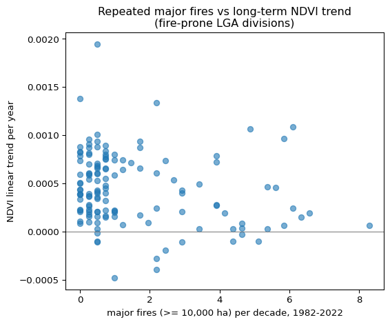

```python
NDVI_YEARS = ndvi.columns.values.astype(float)

def linear_trend(row):
    slope, _ = np.polyfit(NDVI_YEARS, row.values.astype(float), 1)
    return slope

ndvi_trend = ndvi.apply(linear_trend, axis=1).rename("ndvi_trend_per_yr").reset_index()
n_major = (major[major["year"].between(1982, 2022)].groupby(["ADM1_NAME", "ADM2_NAME"])["year"].nunique()
           .rename("n_major_fire_years").reset_index())
ndvi_trend = ndvi_trend.merge(n_major, on=["ADM1_NAME", "ADM2_NAME"], how="left")
ndvi_trend["n_major_fire_years"] = ndvi_trend["n_major_fire_years"].fillna(0)
ndvi_trend["major_fires_per_decade"] = ndvi_trend["n_major_fire_years"] / 41 * 10

corr_ndvi = ndvi_trend[["major_fires_per_decade", "ndvi_trend_per_yr"]].corr().iloc[0, 1]
print(f"Correlation(major_fires_per_decade, NDVI trend/yr) across {len(ndvi_trend)} fire-prone divisions: {corr_ndvi:.3f}")

fig, ax = plt.subplots(figsize=(6, 5))
ax.scatter(ndvi_trend["major_fires_per_decade"], ndvi_trend["ndvi_trend_per_yr"], alpha=0.6)
ax.axhline(0, color="grey", lw=0.8)
ax.set_xlabel("major fires (>= 10,000 ha) per decade, 1982-2022")
ax.set_ylabel("NDVI linear trend per year")
ax.set_title("Repeated major fires vs long-term NDVI trend\n(fire-prone LGA divisions)")
plt.tight_layout()
plt.show()
```

## 4.2 Sightings-share trend vs. major-fire frequency

```
Correlation(major_fires_per_decade, sightings-share trend) across 67 divisions: -0.329
```

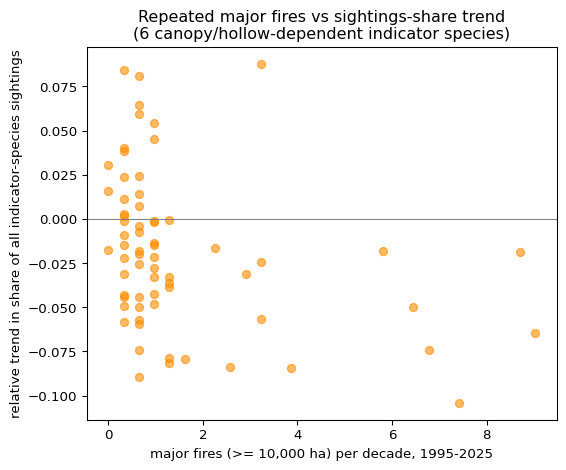

```python
YEAR_MIN, YEAR_MAX = 1995, 2025  # sightings are too sparse before ~1995 to trust a yearly share
rows = []
for (state, div), g in div_year.groupby(["ADM1_NAME", "ADM2_NAME"]):
    g = g[g["year"].between(YEAR_MIN, YEAR_MAX)].sort_values("year")
    if len(g) < 8:
        continue
    slope, _ = np.polyfit(g["year"].values.astype(float), g["share"].values.astype(float), 1)
    rel_slope = slope / g["share"].mean() if g["share"].mean() > 0 else np.nan
    my = major[(major.ADM1_NAME == state) & (major.ADM2_NAME == div) & (major.year.between(YEAR_MIN, YEAR_MAX))]
    rows.append({"ADM1_NAME": state, "ADM2_NAME": div, "share_trend_rel_per_yr": rel_slope,
                 "major_fires_per_decade": my["year"].nunique() / (YEAR_MAX - YEAR_MIN + 1) * 10})
sightings_trend = pd.DataFrame(rows)

corr_sight = sightings_trend[["major_fires_per_decade", "share_trend_rel_per_yr"]].corr().iloc[0, 1]
print(f"Correlation(major_fires_per_decade, sightings-share trend) across {len(sightings_trend)} divisions: {corr_sight:.3f}")

fig, ax = plt.subplots(figsize=(6, 5))
ax.scatter(sightings_trend["major_fires_per_decade"], sightings_trend["share_trend_rel_per_yr"], alpha=0.6, color="darkorange")
ax.axhline(0, color="grey", lw=0.8)
ax.set_xlabel("major fires (>= 10,000 ha) per decade, 1995-2025")
ax.set_ylabel("relative trend in share of all indicator-species sightings")
ax.set_title("Repeated major fires vs sightings-share trend\n(6 canopy/hollow-dependent indicator species)")
plt.tight_layout()
plt.show()
```

## 4.3 Case studies

The fire-prone divisions with the largest single recorded fire *and* enough sighting data to be informative (>= 1,000 total sightings), NDVI and sightings-share plotted side by side with major-fire years marked.

```
Case-study divisions (largest single recorded fire, with enough sighting data to be informative):
 - Lithgow (C) (New South Wales)
 - Walcha (A) (New South Wales)
 - Kangaroo Island (DC) (South Australia)
 - Clarence Valley (A) (New South Wales)
```

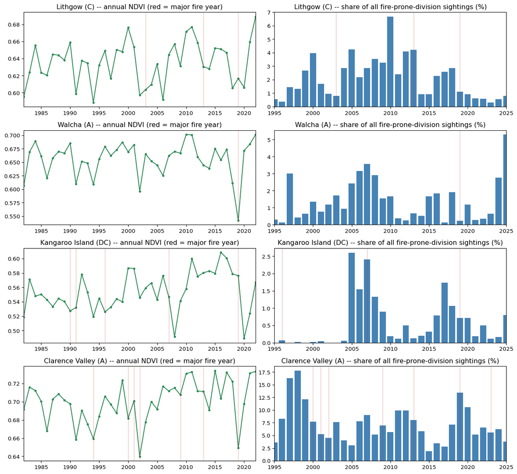

```python
case_study_candidates = (
    major.groupby(["ADM1_NAME", "ADM2_NAME"])
    .agg(max_single_fire_ha=("max_area_ha", "max"))
    .reset_index()
    .merge(div_year.groupby(["ADM1_NAME", "ADM2_NAME"])["sightings"].sum().rename("total_sightings").reset_index(),
           on=["ADM1_NAME", "ADM2_NAME"])
)
case_study_divs = list(
    case_study_candidates[case_study_candidates["total_sightings"] >= 1000]
    .sort_values("max_single_fire_ha", ascending=False)
    .head(4)[["ADM1_NAME", "ADM2_NAME"]]
    .itertuples(index=False, name=None)
)
print("Case-study divisions (largest single recorded fire, with enough sighting data to be informative):")
for state, div in case_study_divs:
    print(" -", div, f"({state})")

div_year_share_pct = div_year.copy()
div_year_share_pct["share_pct"] = 100 * div_year_share_pct["share"]

fig, axes = plt.subplots(max(len(case_study_divs), 1), 2, figsize=(13, 3 * max(len(case_study_divs), 1)))
if len(case_study_divs) == 1:
    axes = axes.reshape(1, -1)
for i, (state, div) in enumerate(case_study_divs):
    ndvi_row = ndvi.loc[(state, div)]
    fy = sorted(major[(major.ADM1_NAME == state) & (major.ADM2_NAME == div)]["year"].unique())

    ax = axes[i, 0]
    ax.plot(ndvi_row.index, ndvi_row.values, marker="o", ms=3, color="seagreen")
    for y in fy:
        if y in ndvi_row.index:
            ax.axvline(y, color="firebrick", alpha=0.15, lw=2)
    ax.set_title(f"{div} -- annual NDVI (red = major fire year)")
    ax.set_xlim(1982, 2022)

    ax2 = axes[i, 1]
    g = div_year_share_pct[(div_year_share_pct.ADM1_NAME == state) & (div_year_share_pct.ADM2_NAME == div)]
    g = g.set_index("year")["share_pct"].reindex(range(YEAR_MIN, YEAR_MAX + 1), fill_value=0)
    ax2.bar(g.index, g.values, color="steelblue")
    for y in fy:
        if YEAR_MIN <= y <= YEAR_MAX:
            ax2.axvline(y, color="firebrick", alpha=0.15, lw=2)
    ax2.set_title(f"{div} -- share of all fire-prone-division sightings (%)")
    ax2.set_xlim(YEAR_MIN, YEAR_MAX)

plt.tight_layout()
plt.show()
```

## 4.4 Q1 summary

Correlation across fire-prone divisions is -0.20 for (major fires/decade, NDVI trend) and -0.33 for (major fires/decade, sightings-share trend). NDVI trend at this LGA-averaged, annual resolution shows little to no relationship with raw fire frequency – vegetation greenness tends to rebound to, or above, its pre-fire level within a few years, repeatedly, regardless of how often a division has burnt. Wildlife-sightings share shows a clearer negative tendency: divisions burning more often lose a larger share of the regional sighting record over time, even after normalising for the nationwide rise in reporting effort. Read together this is consistent with a real ecological asymmetry rather than a data artefact – leaf-level greenness recovers on a vegetation-growth timescale of a few years, while hollow-dependent species depend on habitat *structure* (large old trees with hollows) that takes decades to regenerate. These are exploratory division-level associations and do not control for heat, remoteness, or drought. Q2 therefore adds heat exposure and moves to event-level testing.

# 5 Q2 methods – event-level recovery

The analysis unit changes here from *division* to **individual major fire event** (one row per division x fire-year with a fire `>= 10,000 ha`) – this provides more observations than the division-level analysis in Q1 and lets each event’s post-fire heat exposure be measured directly.

**Recovery ratio (RRI)**, adapted from Frazier et al. (2018, *Remote Sensing of Environment* 205:32-45): `RRI = ARI / disturbance magnitude`, where disturbance magnitude is the pre-fire NDVI baseline (mean of the 2 years before the fire) minus the fire-year NDVI value, and ARI is the best post-fire NDVI value (across `fire_year+3`, `+4`, `+5`, whichever are available) minus that same fire-year value. The paper uses a fixed `Y+4`/`Y+5` window on precisely-dated per-pixel LandTrendr breakpoints; here “fire year” is just the annual division-wide composite for that calendar year (a noisier proxy for the true disturbance trough), and the window is the best *available* of `+3`/`+4`/`+5` rather than fixed `+4`/`+5`, because NDVI data ends in 2022 and a fixed window would drop every fire from 2019 onward – including Black Summer. Only defined when the disturbance magnitude is positive. The identical construction is applied to sightings share, with a small constant (`1e-6`) added throughout to avoid divide-by-zero, and is only computed for divisions with a real koala/glider/etc. presence (>= 200 total sightings) to avoid diluting the test with non-habitat divisions.

**Post-fire heat exposure** = mean `hot_days_ge35`/yr over `fire_year` to `fire_year + 3`. **Heat anomaly** = that value minus the *same division’s* long-run mean hot-day count – isolating “was this recovery window unusually hot for this place”, not just re-detecting that e.g. inland Queensland is hotter than alpine NSW.

```python
PRE_YEARS, HEAT_POST_LAG, RECOVERY_POST_LAGS, SMOOTH = 2, 3, [3, 4, 5], 1e-6

records = []
for _, r in major.iterrows():
    state, div, year = r["ADM1_NAME"], r["ADM2_NAME"], int(r["year"])
    key = (state, div)
    if key not in ndvi.index or key not in heat_piv.index:
        continue

    ndvi_row, heat_row = ndvi.loc[key], heat_piv.loc[key]
    pre_years = [year - k for k in range(1, PRE_YEARS + 1)]
    heat_post_years = [year + k for k in range(0, HEAT_POST_LAG + 1)]
    recovery_post_years = [year + k for k in RECOVERY_POST_LAGS]

    pre_ndvi = [v for v in (ndvi_row.get(y) for y in pre_years) if pd.notna(v)]
    y0_ndvi = ndvi_row.get(year)
    post_ndvi = [v for v in (ndvi_row.get(y) for y in recovery_post_years) if pd.notna(v)]
    if not pre_ndvi or pd.isna(y0_ndvi) or not post_ndvi:
        continue
    ndvi_baseline = np.mean(pre_ndvi)
    ndvi_disturbance = ndvi_baseline - y0_ndvi
    if ndvi_disturbance <= 0:
        continue
    ndvi_ratio = (max(post_ndvi) - y0_ndvi) / ndvi_disturbance

    sight_ratio = np.nan
    if key in share_piv.index:
        srow = share_piv.loc[key]
        pre_share = [v for v in (srow.get(y) for y in pre_years) if pd.notna(v)]
        y0_share = srow.get(year)
        post_share = [v for v in (srow.get(y) for y in recovery_post_years) if pd.notna(v)]
        if pre_share and pd.notna(y0_share) and post_share:
            share_baseline = np.mean(pre_share) + SMOOTH
            y0_share_s = y0_share + SMOOTH
            share_disturbance = share_baseline - y0_share_s
            if share_disturbance > 0:
                sight_ratio = (max(post_share) + SMOOTH - y0_share_s) / share_disturbance

    post_heat = [v for v in (heat_row.get(y) for y in heat_post_years) if pd.notna(v)]
    if not post_heat:
        continue
    heat_post_mean = np.mean(post_heat)
    heat_anomaly = heat_post_mean - heat_baseline_mean.get(key, np.nan)

    records.append({
        "ADM1_NAME": state, "ADM2_NAME": div, "fire_year": year,
        "max_area_ha": r["max_area_ha"], "major_fires": r["major_fires"],
        "ndvi_recovery_ratio": ndvi_ratio, "sightings_recovery_ratio": sight_ratio,
        "heat_anomaly_postfire": heat_anomaly,
        "division_total_sightings": total_sightings_per_div.get(key, 0),
    })

events_all = pd.DataFrame(records)
# RRI can be zero/negative (best post-fire value never exceeds the fire-year value); can't log-transform those.
events_all = events_all[events_all["ndvi_recovery_ratio"] > 0].copy()
events_all["log_ndvi_ratio"] = np.log(events_all["ndvi_recovery_ratio"])
events_all["log_severity"] = np.log(events_all["max_area_ha"])

HABITAT_MIN_SIGHTINGS = 200
events = events_all[(events_all["division_total_sightings"] >= HABITAT_MIN_SIGHTINGS)
                     & events_all["sightings_recovery_ratio"].notna()
                     & (events_all["sightings_recovery_ratio"] > 0)].copy()
events["log_sight_ratio"] = np.log(events["sightings_recovery_ratio"])
events["recovery_gap"] = events["log_ndvi_ratio"] - events["log_sight_ratio"]

print(f"{len(events_all)} major-fire events with a usable NDVI recovery ratio + heat exposure "
      f"({events_all['ADM2_NAME'].nunique()} divisions, states: {sorted(events_all['ADM1_NAME'].unique())})")
print(f"{len(events)} of those also have a valid sightings recovery ratio in a habitat division "
      f"({events['ADM2_NAME'].nunique()} divisions, states: {sorted(events['ADM1_NAME'].unique())})")
```

```
400 major-fire events with a usable NDVI recovery ratio + heat exposure (106 divisions, states: ['New South Wales', 'Queensland', 'South Australia', 'Tasmania', 'Western Australia'])
53 of those also have a valid sightings recovery ratio in a habitat division (29 divisions, states: ['New South Wales', 'Queensland'])
```

Two analysis tables are constructed: `events_all` for vegetation recovery and `events` for events that also pass the sightings and habitat-data requirements.

The `>= 200` total-sightings habitat filter means that the wildlife and recovery-gap analyses retain only states where these six indicator species are recorded often enough for analysis. This is an important biogeographic restriction and is addressed in the Limitations section.

# 6 Q2 results – recovery gap under post-fire heat

## 6.1 Descriptive overview

```python
events[["heat_anomaly_postfire", "ndvi_recovery_ratio", "sightings_recovery_ratio", "recovery_gap"]].describe()
```

|  | heat_anomaly_postfire | ndvi_recovery_ratio | sightings_recovery_ratio | recovery_gap |
| --- | --- | --- | --- | --- |
| count | 53.000000 | 53.000000 | 53.000000 | 53.000000 |
| mean | 2.445986 | 4.306883 | 11.486999 | -0.072387 |
| std | 5.239923 | 10.165986 | 26.820272 | 2.345963 |
| min | -4.692032 | 0.079690 | 0.013924 | -3.646718 |
| 25% | -0.037209 | 1.236241 | 0.945405 | -1.717235 |
| 50% | 1.309639 | 2.203394 | 1.532142 | -0.102194 |
| 75% | 2.842186 | 3.697023 | 9.180064 | 1.461929 |
| max | 19.456584 | 74.078020 | 162.002857 | 6.031864 |

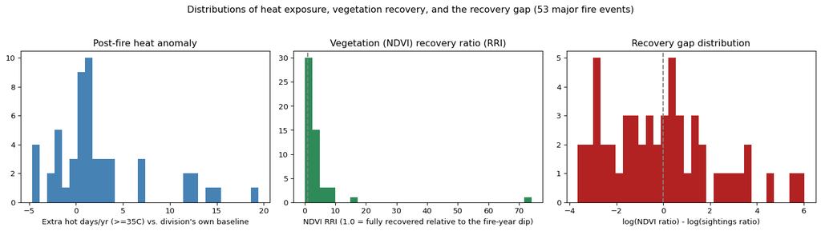

```python
fig, axes = plt.subplots(1, 3, figsize=(15, 4))
axes[0].hist(events["heat_anomaly_postfire"], bins=30, color="steelblue")
axes[0].set_title("Post-fire heat anomaly")
axes[0].set_xlabel("Extra hot days/yr (>=35C) vs. division's own baseline")

axes[1].hist(events["ndvi_recovery_ratio"], bins=30, color="seagreen")
axes[1].axvline(1.0, color="grey", ls="--")
axes[1].set_title("Vegetation (NDVI) recovery ratio (RRI)")
axes[1].set_xlabel("NDVI RRI (1.0 = fully recovered relative to the fire-year dip)")

axes[2].hist(events["recovery_gap"], bins=30, color="firebrick")
axes[2].axvline(0, color="grey", ls="--")
axes[2].set_title("Recovery gap distribution")
axes[2].set_xlabel("log(NDVI ratio) - log(sightings ratio)")

fig.suptitle(f"Distributions of heat exposure, vegetation recovery, and the recovery gap ({len(events)} major fire events)", y=1.04)
plt.tight_layout()
plt.show()
```

## 6.2 Spatial pattern of the recovery gap

Each fire-prone division’s **mean recovery gap** across all its major-fire events. Red = vegetation recovers substantially better than wildlife (the “greenwashing risk” divisions); blue = the two track each other. The join below matches on **both** `ADM1_NAME` and `ADM2_NAME` (not `ADM2_NAME` alone), since some LGA names recur across state borders (e.g. “Campbelltown (C)” exists in both NSW and SA) and a name-only join could silently misattribute those divisions on the map.

```python
div_agg = events.groupby(["ADM1_NAME", "ADM2_NAME"]).agg(
    n_events=("recovery_gap", "size"),
    mean_recovery_gap=("recovery_gap", "mean"),
    mean_heat_anomaly=("heat_anomaly_postfire", "mean"),
    mean_ndvi_ratio=("ndvi_recovery_ratio", "mean"),
    mean_sightings_ratio=("sightings_recovery_ratio", "mean"),
).reset_index()

geo = admin2.merge(div_agg[["ADM1_NAME", "ADM2_NAME"]], on=["ADM1_NAME", "ADM2_NAME"], how="inner").reset_index(drop=True)
geo["geometry"] = geo.geometry.simplify(0.01, preserve_topology=True)  # keeps the embedded map lightweight
geojson = json.loads(geo.to_json())

div_agg_labelled = div_agg.rename(columns={
    "ADM1_NAME": "State", "mean_recovery_gap": "Mean recovery gap",
    "mean_heat_anomaly": "Mean post-fire heat anomaly (extra hot days/yr)",
    "mean_ndvi_ratio": "Mean NDVI recovery ratio", "mean_sightings_ratio": "Mean sightings recovery ratio",
    "n_events": "Number of major fire events",
})

fig_map = px.choropleth_map(
    div_agg_labelled, geojson=geojson, locations="ADM2_NAME", featureidkey="properties.ADM2_NAME",
    color="Mean recovery gap", color_continuous_scale="RdBu_r", color_continuous_midpoint=0,
    hover_name="ADM2_NAME",
    hover_data={"State": True, "Mean recovery gap": ":.2f",
                "Mean post-fire heat anomaly (extra hot days/yr)": ":.1f",
                "Mean NDVI recovery ratio": ":.2f", "Mean sightings recovery ratio": ":.2f",
                "Number of major fire events": True},
    map_style="carto-positron", zoom=3.2, center={"lat": -28, "lon": 145}, opacity=0.75, height=650,
)
fig_map.update_layout(
    title=dict(text="Mean post-fire recovery gap by fire-prone division<br>"
                     "<sup>Red = vegetation recovers better than wildlife (widening blind-spot risk); Blue = the two track together</sup>",
               x=0.02, y=0.98),
    margin=dict(l=0, r=0, t=70, b=0),
    coloraxis_colorbar=dict(title="Mean recovery gap<br>(+ = vegetation<br>outpaces wildlife)"),
)
fig_map
```

[interactive chart not shown]

## 6.3 Recovery patterns by heat exposure

### 6.3.1 Diverging recovery lines

Both recovery ratios (log scale, 0 = back to baseline) plotted against post-fire heat exposure, with a trend line fit to each.

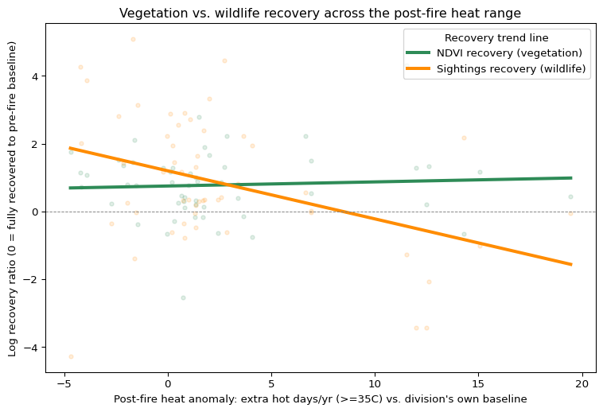

```python
fig, ax = plt.subplots(figsize=(8, 5.5))
xs = np.linspace(events["heat_anomaly_postfire"].min(), events["heat_anomaly_postfire"].max(), 50)
z_ndvi = np.polyfit(events["heat_anomaly_postfire"], events["log_ndvi_ratio"], 1)
z_sight = np.polyfit(events["heat_anomaly_postfire"], events["log_sight_ratio"], 1)

ax.scatter(events["heat_anomaly_postfire"], events["log_ndvi_ratio"], alpha=0.15, s=14, color="seagreen")
ax.scatter(events["heat_anomaly_postfire"], events["log_sight_ratio"], alpha=0.15, s=14, color="darkorange")
ax.plot(xs, np.polyval(z_ndvi, xs), color="seagreen", lw=3, label="NDVI recovery (vegetation)")
ax.plot(xs, np.polyval(z_sight, xs), color="darkorange", lw=3, label="Sightings recovery (wildlife)")
ax.axhline(0, color="grey", lw=0.7, ls="--")
ax.set_xlabel("Post-fire heat anomaly: extra hot days/yr (>=35C) vs. division's own baseline")
ax.set_ylabel("Log recovery ratio (0 = fully recovered to pre-fire baseline)")
ax.set_title("Vegetation vs. wildlife recovery across the post-fire heat range")
ax.legend(title="Recovery trend line", loc="upper right")
plt.tight_layout()
plt.show()
```

### 6.3.2 The gap by heat tercile

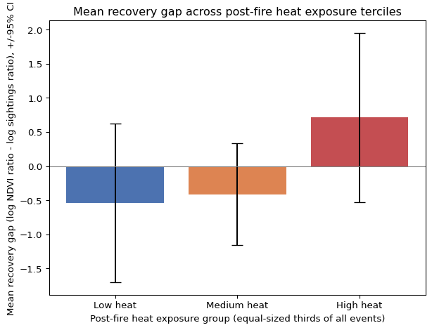

| heat_tercile | mean_gap | se_gap |
| --- | --- | --- |
| Low heat | -0.536178 | 0.594045 |
| Medium heat | -0.410984 | 0.378890 |
| High heat | 0.711189 | 0.632145 |

```python
events["heat_tercile"] = pd.qcut(events["heat_anomaly_postfire"], 3, labels=["Low heat", "Medium heat", "High heat"])
tercile = events.groupby("heat_tercile", observed=True).agg(
    mean_gap=("recovery_gap", "mean"), se_gap=("recovery_gap", lambda x: x.std() / np.sqrt(len(x)))
)
fig, ax = plt.subplots(figsize=(6.5, 5))
ax.bar(tercile.index, tercile["mean_gap"], yerr=1.96 * tercile["se_gap"], capsize=6,
       color=["#4c72b0", "#dd8452", "#c44e52"])
ax.axhline(0, color="grey", lw=0.8)
ax.set_xlabel("Post-fire heat exposure group (equal-sized thirds of all events)")
ax.set_ylabel("Mean recovery gap (log NDVI ratio - log sightings ratio), +/-95% CI")
ax.set_title("Mean recovery gap across post-fire heat exposure terciles")
plt.tight_layout()
plt.show()
tercile
```

## 6.4 Statistical evidence

Two groups of tests are reported: first, whether **each recovery ratio on its own** responds to heat; second, whether the **gap** between the two responds to heat. Reported values are calculated directly from the analysis tables rather than hardcoded.

### 6.4.1 Do the individual recovery ratios respond to heat?

**Spearman rank correlation** (no linearity/distribution assumptions):

```python
r1, p1 = stats.spearmanr(events_all["heat_anomaly_postfire"], events_all["ndvi_recovery_ratio"])
r2, p2 = stats.spearmanr(events["heat_anomaly_postfire"], events["sightings_recovery_ratio"])
print(f"heat anomaly vs NDVI recovery ratio:       rho={r1:.3f}, p={p1:.3g}, n={len(events_all)}")
print(f"heat anomaly vs sightings recovery ratio:  rho={r2:.3f}, p={p2:.3g}, n={len(events)}")
```

```
heat anomaly vs NDVI recovery ratio:       rho=-0.136, p=0.00644, n=400
heat anomaly vs sightings recovery ratio:  rho=-0.295, p=0.0319, n=53
```

**Mann-Whitney U** (median-split high-heat vs low-heat events; one-sided since the hypothesis has a predicted direction):

```python
med = events_all["heat_anomaly_postfire"].median()
hi, lo = events_all.loc[events_all.heat_anomaly_postfire > med, "ndvi_recovery_ratio"], \
         events_all.loc[events_all.heat_anomaly_postfire <= med, "ndvi_recovery_ratio"]
u1, pu1 = stats.mannwhitneyu(hi, lo, alternative="less")
print(f"NDVI recovery ratio      -- high-heat median={hi.median():.4f} (n={len(hi)}), "
      f"low-heat median={lo.median():.4f} (n={len(lo)}), U={u1:.0f}, p(high<low)={pu1:.3g}")

med_s = events["heat_anomaly_postfire"].median()
hi_s, lo_s = events.loc[events.heat_anomaly_postfire > med_s, "sightings_recovery_ratio"], \
             events.loc[events.heat_anomaly_postfire <= med_s, "sightings_recovery_ratio"]
u2, pu2 = stats.mannwhitneyu(hi_s, lo_s, alternative="less")
print(f"Sightings recovery ratio -- high-heat median={hi_s.median():.4f} (n={len(hi_s)}), "
      f"low-heat median={lo_s.median():.4f} (n={len(lo_s)}), U={u2:.0f}, p(high<low)={pu2:.3g}")
```

```
NDVI recovery ratio      -- high-heat median=1.4315 (n=200), low-heat median=1.6781 (n=200), U=17739, p(high<low)=0.0253
Sightings recovery ratio -- high-heat median=1.3949 (n=26), low-heat median=4.2032 (n=27), U=264, p(high<low)=0.0619
```

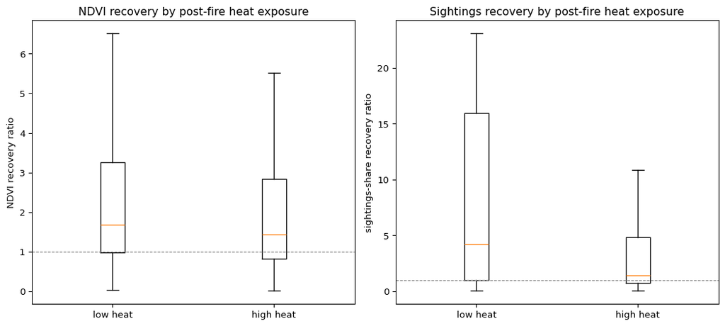

```python
fig, axes = plt.subplots(1, 2, figsize=(11, 5))
axes[0].boxplot([lo, hi], tick_labels=["low heat", "high heat"], showfliers=False)
axes[0].axhline(1.0, color="grey", ls="--", lw=0.8)
axes[0].set_ylabel("NDVI recovery ratio")
axes[0].set_title("NDVI recovery by post-fire heat exposure")
axes[1].boxplot([lo_s, hi_s], tick_labels=["low heat", "high heat"], showfliers=False)
axes[1].axhline(1.0, color="grey", ls="--", lw=0.8)
axes[1].set_ylabel("sightings-share recovery ratio")
axes[1].set_title("Sightings recovery by post-fire heat exposure")
plt.tight_layout()
plt.show()
```

**OLS regression with cluster-robust standard errors** (clustered by division, since events within the same division aren’t independent): `log(recovery ratio) ~ heat_anomaly + log(severity)`.

```python
X = events_all[["heat_anomaly_postfire", "log_severity"]].copy()
X = (X - X.mean()) / X.std()
X.insert(0, "const", 1.0)
vif = {c: variance_inflation_factor(X.values, i) for i, c in enumerate(X.columns) if c != "const"}
print("VIF (collinearity check):", vif)
```

```
VIF (collinearity check): {'heat_anomaly_postfire': np.float64(1.0223889824668446), 'log_severity': np.float64(1.0223889824668446)}
```

```python
m1 = smf.ols("log_ndvi_ratio ~ heat_anomaly_postfire + log_severity", data=events_all) \
        .fit(cov_type="cluster", cov_kwds={"groups": events_all["ADM2_NAME"]})
print(m1.summary())
```

```
                            OLS Regression Results
==============================================================================
Dep. Variable:         log_ndvi_ratio   R-squared:                       0.009
Model:                            OLS   Adj. R-squared:                  0.004
Method:                 Least Squares   F-statistic:                     2.787
Date:                Wed, 22 Jul 2026   Prob (F-statistic):             0.0661
Time:                        19:07:19   Log-Likelihood:                -628.45
No. Observations:                 400   AIC:                             1263.
Df Residuals:                     397   BIC:                             1275.
Df Model:                           2
Covariance Type:              cluster
=========================================================================================
                            coef    std err          z      P>|z|      [0.025      0.975]
-----------------------------------------------------------------------------------------
Intercept                 0.4140      0.485      0.854      0.393      -0.536       1.364
heat_anomaly_postfire    -0.0140      0.006     -2.345      0.019      -0.026      -0.002
log_severity              0.0123      0.047      0.265      0.791      -0.079       0.104
==============================================================================
Omnibus:                       34.167   Durbin-Watson:                   1.994
Prob(Omnibus):                  0.000   Jarque-Bera (JB):              145.317
Skew:                           0.148   Prob(JB):                     2.78e-32
Kurtosis:                       5.938   Cond. No.                         107.
==============================================================================

Notes:
[1] Standard Errors are robust to cluster correlation (cluster)
```

```python
m2 = smf.ols("log_sight_ratio ~ heat_anomaly_postfire + log_severity", data=events) \
        .fit(cov_type="cluster", cov_kwds={"groups": events["ADM2_NAME"]})
print(m2.summary())
```

```
                            OLS Regression Results
==============================================================================
Dep. Variable:        log_sight_ratio   R-squared:                       0.170
Model:                            OLS   Adj. R-squared:                  0.137
Method:                 Least Squares   F-statistic:                     3.610
Date:                Wed, 22 Jul 2026   Prob (F-statistic):             0.0403
Time:                        19:07:20   Log-Likelihood:                -105.13
No. Observations:                  53   AIC:                             216.3
Df Residuals:                      50   BIC:                             222.2
Df Model:                           2
Covariance Type:              cluster
=========================================================================================
                            coef    std err          z      P>|z|      [0.025      0.975]
-----------------------------------------------------------------------------------------
Intercept                 4.2993      1.964      2.189      0.029       0.449       8.149
heat_anomaly_postfire    -0.1109      0.070     -1.587      0.113      -0.248       0.026
log_severity             -0.3037      0.202     -1.500      0.134      -0.700       0.093
==============================================================================
Omnibus:                        4.545   Durbin-Watson:                   1.530
Prob(Omnibus):                  0.103   Jarque-Bera (JB):                4.007
Skew:                          -0.357   Prob(JB):                        0.135
Kurtosis:                       4.142   Cond. No.                         114.
==============================================================================

Notes:
[1] Standard Errors are robust to cluster correlation (cluster)
```

VIF ~1.02 for both predictors – heat exposure and fire severity are not confounded with each other, so their coefficients are independently interpretable. Fire severity (`log_severity`) is not significant (p = 0.791 ≥ 0.05) for NDVI and not significant (p = 0.134 ≥ 0.05) for sightings. **Post-fire heat anomaly is significant (p = 0.019 < 0.05) for NDVI (n=400) and not significant (p = 0.113 ≥ 0.05) for sightings (n=53)** in the current data. This should be interpreted alongside the gap-focused tests below, because the relative strength of the two outcomes can shift as more states and years of data are added.

Converting the coefficients to an interpretable scale – a division experiencing **20 more hot days/yr than its own long-run average** in the recovery window after a major fire is associated with:

```python
ndvi_effect = np.exp(m1.params["heat_anomaly_postfire"] * 20)
sight_effect = np.exp(m2.params["heat_anomaly_postfire"] * 20)
print(f"NDVI recovery ratio      x {ndvi_effect:.3f}   ({(1-ndvi_effect)*100:.1f}% lower relative recovery)")
print(f"Sightings recovery ratio x {sight_effect:.3f}   ({(1-sight_effect)*100:.1f}% lower relative recovery)")
```

```
NDVI recovery ratio      x 0.755   (24.5% lower relative recovery)
Sightings recovery ratio x 0.109   (89.1% lower relative recovery)
```

### 6.4.2 Does the vegetation-vs-sightings recovery gap widen with heat?

Four further, complementary tests on the **gap** variable itself (`recovery_gap = log_ndvi_ratio - log_sight_ratio`), from least to most model-dependent, so the conclusion doesn’t rest on one modelling choice.

**Spearman rank correlation:**

```python
r3, p3 = stats.spearmanr(events["heat_anomaly_postfire"], events["recovery_gap"])
print(f"Spearman(heat anomaly, recovery gap): rho={r3:.3f}, p={p3:.4g}, n={len(events)}")
```

```
Spearman(heat anomaly, recovery gap): rho=0.282, p=0.04062, n=53
```

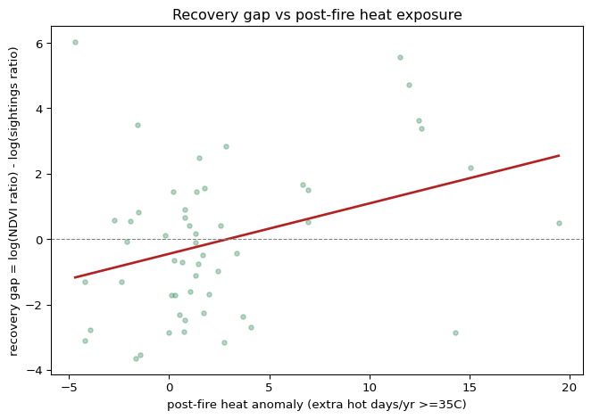

```python
fig, ax = plt.subplots(figsize=(7, 5))
ax.scatter(events["heat_anomaly_postfire"], events["recovery_gap"], alpha=0.35, s=15, color="seagreen")
z3 = np.polyfit(events["heat_anomaly_postfire"], events["recovery_gap"], 1)
xs3 = np.linspace(events["heat_anomaly_postfire"].min(), events["heat_anomaly_postfire"].max(), 50)
ax.plot(xs3, np.polyval(z3, xs3), color="firebrick", lw=2)
ax.axhline(0, color="grey", lw=0.8, ls="--")
ax.set_xlabel("post-fire heat anomaly (extra hot days/yr >=35C)")
ax.set_ylabel("recovery gap = log(NDVI ratio) - log(sightings ratio)")
ax.set_title("Recovery gap vs post-fire heat exposure")
plt.tight_layout()
plt.show()
```

**OLS, cluster-robust SEs, on the gap directly:**

```python
m3 = smf.ols("recovery_gap ~ heat_anomaly_postfire + log_severity", data=events) \
        .fit(cov_type="cluster", cov_kwds={"groups": events["ADM2_NAME"]})
print(m3.summary())
```

```
                            OLS Regression Results
==============================================================================
Dep. Variable:           recovery_gap   R-squared:                       0.170
Model:                            OLS   Adj. R-squared:                  0.137
Method:                 Least Squares   F-statistic:                     3.387
Date:                Wed, 22 Jul 2026   Prob (F-statistic):             0.0482
Time:                        19:07:20   Log-Likelihood:                -114.96
No. Observations:                  53   AIC:                             235.9
Df Residuals:                      50   BIC:                             241.8
Df Model:                           2
Covariance Type:              cluster
=========================================================================================
                            coef    std err          z      P>|z|      [0.025      0.975]
-----------------------------------------------------------------------------------------
Intercept                -5.8809      2.811     -2.092      0.036     -11.391      -0.371
heat_anomaly_postfire     0.0996      0.077      1.296      0.195      -0.051       0.250
log_severity              0.5320      0.280      1.897      0.058      -0.018       1.082
==============================================================================
Omnibus:                        4.567   Durbin-Watson:                   1.729
Prob(Omnibus):                  0.102   Jarque-Bera (JB):                3.516
Skew:                           0.579   Prob(JB):                        0.172
Kurtosis:                       3.499   Cond. No.                         114.
==============================================================================

Notes:
[1] Standard Errors are robust to cluster correlation (cluster)
```

**Cluster bootstrap on the slope** (resampling whole divisions, not individual events, 2,000 times – checks the regression result isn’t an artefact of one or two divisions with unusually many events):

```python
rng = np.random.default_rng(42)
divs = events["ADM2_NAME"].unique()
boot_slopes = []
for _ in range(2000):
    sample_divs = rng.choice(divs, size=len(divs), replace=True)
    boot_df = pd.concat([events[events.ADM2_NAME == d] for d in sample_divs], ignore_index=True)
    boot_slopes.append(np.polyfit(boot_df["heat_anomaly_postfire"], boot_df["recovery_gap"], 1)[0])
boot_slopes = np.array(boot_slopes)
ci_lo, ci_hi = np.percentile(boot_slopes, [2.5, 97.5])
print(f"bootstrap slope: mean={boot_slopes.mean():.4f}, 95% CI=[{ci_lo:.4f}, {ci_hi:.4f}]")
print(f"fraction of 2,000 resamples with a positive slope: {(boot_slopes > 0).mean():.3f}")
```

```
bootstrap slope: mean=0.1416, 95% CI=[-0.0548, 0.3531]
fraction of 2,000 resamples with a positive slope: 0.906
```

**Kruskal-Wallis across heat terciles:**

```python
kw_stat, kw_p = stats.kruskal(
    events[events.heat_tercile == "Low heat"]["recovery_gap"],
    events[events.heat_tercile == "Medium heat"]["recovery_gap"],
    events[events.heat_tercile == "High heat"]["recovery_gap"],
)
print(f"Kruskal-Wallis H={kw_stat:.3f}, p={kw_p:.4g}")
```

```
Kruskal-Wallis H=2.761, p=0.2515
```

**Formal interaction test** – stack both recovery ratios into one long-format regression with a `metric x heat` interaction term; if significant, this confirms NDVI and sightings respond *differently* to heat, as a fully independent cross-check that doesn’t rely on the `recovery_gap` variable’s construction at all:

```python
long_df = pd.concat([
    events.assign(metric="ndvi", log_ratio=events["log_ndvi_ratio"]),
    events.assign(metric="sightings", log_ratio=events["log_sight_ratio"]),
], ignore_index=True)
m_int = smf.ols("log_ratio ~ heat_anomaly_postfire * C(metric) + log_severity", data=long_df) \
           .fit(cov_type="cluster", cov_kwds={"groups": long_df["ADM2_NAME"]})
print(m_int.summary())
```

```
                            OLS Regression Results
==============================================================================
Dep. Variable:              log_ratio   R-squared:                       0.115
Model:                            OLS   Adj. R-squared:                  0.080
Method:                 Least Squares   F-statistic:                     1.815
Date:                Wed, 22 Jul 2026   Prob (F-statistic):              0.154
Time:                        19:09:34   Log-Likelihood:                -190.36
No. Observations:                 106   AIC:                             390.7
Df Residuals:                     101   BIC:                             404.0
Df Model:                           4
Covariance Type:              cluster
================================================================================================================
                                                   coef    std err          z      P>|z|      [0.025      0.975]
----------------------------------------------------------------------------------------------------------------
Intercept                                        1.1342      1.068      1.062      0.288      -0.958       3.227
C(metric)[T.sightings]                           0.4492      0.371      1.212      0.225      -0.277       1.175
heat_anomaly_postfire                            0.0160      0.032      0.498      0.619      -0.047       0.079
heat_anomaly_postfire:C(metric)[T.sightings]    -0.1541      0.105     -1.471      0.141      -0.359       0.051
log_severity                                    -0.0377      0.099     -0.379      0.705      -0.232       0.157
==============================================================================
Omnibus:                       12.860   Durbin-Watson:                   1.626
Prob(Omnibus):                  0.002   Jarque-Bera (JB):               27.882
Skew:                          -0.387   Prob(JB):                     8.82e-07
Kurtosis:                       5.390   Cond. No.                         117.
==============================================================================

Notes:
[1] Standard Errors are robust to cluster correlation (cluster)
```

```
=== Summary of the gap-focused tests ===
Spearman (gap)               p=0.04062  -> significant
OLS cluster-robust (gap)     p=0.195  -> not significant
Kruskal-Wallis (terciles)    p=0.2515  -> not significant
Metric x heat interaction    p=0.1414  -> not significant

90.6% of 2,000 cluster-bootstrap resamples give a positive slope (direction-only evidence, no p-value).

1 of the 4 formal significance tests above currently reach p < 0.05; all 4 + the bootstrap agree on the *direction* of the effect (positive: heat widens the gap).
```

### 6.4.3 Assumption checks and interpretation

[output not shown]

# 7 Limitations

- **Correlational, not causal.** Heat, fire severity, drought, and remoteness are entangled; this cannot rule out a third factor (e.g. drought, which drives both worse fire years and low NDVI) acting on both sides at once.
- **Sightings are presence-only and effort-biased.** Reporting effort has grown enormously nation-wide since the 1990s; the share-of-year-total normalisation and the `>= 200`-sightings habitat filter reduce but do not eliminate this. Treat the sightings result as “recorded presence”, not population size.
- **The sightings-side and recovery-gap tests currently run on whichever state(s) clear the `>= 200`-sightings habitat filter.** The six indicator species are essentially south-eastern-Australia forest species (koala, greater glider, yellow-bellied glider, yellow-tailed black-cockatoo, powerful owl, little lorikeet) and are almost never recorded in WA/NT/TAS/SA regardless of how much fire/NDVI data exists there, so this is a biogeographic fact rather than a processing bug – but it does mean the sightings-side and recovery-gap conclusions cannot be read as claims about Australian wildlife broadly, only about the state(s) where these particular species occur in numbers.
- **The 10,000 ha “major fire” threshold, and the `MIN_FIRE_COUNT` / `MIN_AVG_AREA_HA` fire-prone-division thresholds, are design choices**, not physical constants – chosen to separate wildfires from routine hazard-reduction burns and to target divisions with frequent, *significant* fire activity. Victoria’s ~440k small recorded burns (median ~11 ha) currently fail the average-area threshold and drop out of the fire-prone list entirely; lowering `MIN_AVG_AREA_HA` would bring it back in.
- **The recovery ratio is an adapted RRI, not the original Frazier et al. (2018) formula.** Their method locates the disturbance trough precisely from per-pixel LandTrendr segmentation of Landsat and uses a fixed Y+4/Y+5 recovery window; here the “fire-year” value is just the annual division-wide composite for that calendar year (a noisier proxy for the true trough), and the recovery window is the best available of Y+3/Y+4/Y+5 rather than fixed Y+4/Y+5, to keep 2019-onward fires (including Black Summer) inside the NDVI data’s 2022 cutoff.
- **The RRI’s disturbance-magnitude requirement (a measurable dip in the fire year) sharply cuts the usable sample**, especially for sightings. This is the main reason the direct NDVI-heat and sightings-heat relationships can trade places in significance as more data or states are added, and why the gap-focused tests carry meaningful sampling uncertainty.
- **The heat-exposure window (`fire_year` to `fire_year+3`) does not match the recovery-ratio window** (best available of Y+3/Y+4/Y+5), so the two are not measuring exactly the same horizon.
- **Multiple major fires can overlap** within a division’s post-fire window (a second fire before the recovery year used); this event table does not exclude that case – it measures recovery as observed, whatever happened in between.
- **Fire-to-division spatial join uses fire-polygon centroids**, and the Northern Territory layer’s border-adjacent records are not deduplicated against the QLD/WA/SA loaders’ own records – a small double-counting risk near state borders that this report flags rather than resolves.
- **Q1 and Q2 use different units of analysis** (division vs. event) and different fire-frequency windows (1982-2022 vs. the RRI recovery windows), so their correlation strengths are not directly comparable to each other – each should be read as its own self-contained test.

# 8 Conclusions

**Q1 – does fire frequency alone predict weaker recovery?** Not for vegetation: NDVI shows essentially no cumulative “weaker recovery each time” pattern, rebounding to, or above, pre-fire levels within a few years regardless of fire frequency. Wildlife sightings tell a different story – divisions that burn more often tend to lose *share* of the regional sighting record over time, consistent with habitat *structure* (old trees with hollows) recovering on a much slower timescale than leaf-level greenness.

That divergence is the real finding: a monitoring approach that leans on vegetation greenness as a stand-in for “habitat recovered” risks looking *more* reassuring, not less, exactly as post-fire conditions get hotter for the animals living there – the most concerning shape a blind spot can take, because it erodes the warning signal precisely when the warning is most needed. Given the small, geographically narrow sightings-side sample currently available, this should be read as a real but not yet fully settled signal, not a precisely-estimated effect size – and one worth re-testing as sightings data grows across more of the country.

# 9 Appendix A: feature definitions

[output not shown]

# 10 References

Frazier, R. J., Coops, N. C., Wulder, M. A., Hermosilla, T., & White, J. C. (2018). Analyzing spatial and temporal variability in short-term rates of post-fire vegetation return from Landsat time series. *Remote Sensing of Environment, 205*, 32-45. https://doi.org/10.1016/j.rse.2017.11.007